The Labyrinth of Multiple Testing: how to avoid the pitfall of false positives Introduction to Hypothesis testing Livio Finos and Angela Andreella

In this laboratory, we will understand the concept of $H_0$, $H_1$, $\alpha$, p-value and FWER using simple simulations.

# 1 One single hypothesis

## 1.1 $H_0$ true

Suppose we conducted an experiment in which a new (maximum) blood pressure-lowering drug is compared with the standard drug. The response of primary interest is `Y`: the (maximum) pressure. You have three subjects in each sample.

The hypothesis test of interest is the equality of the means of the two samples (new blood pressure-lowering drug vs standard drug).

**Exercise**

1. Generate a *plausible* dataset under the assumption that the two drugs are equivalent.
2. Now compute a statistical test (and associated p-values) to test if the two drugs are equivalent.
3. Did you reject $H_0: \mu_{standard}=\mu_{new}$? Are you surprised?

*If you do not like the example, you can imagine a completely different example. What we are interested in is the p-value generated under the null hypothesis $H_0: \mu_{standard}=\mu_{new}$.*

**Possible solution**

```r
set.seed(17)
datas=data.frame(drug=c("standard","standard","standard",
                        "new","new","new"),
                pressure=rnorm(6,mean = 150,sd = 10))
datas
```

| drug | pressure |
| --- | --- |
| standard | 139.8499 |
| standard | 149.2036 |
| standard | 147.6701 |
| new | 141.8273 |
| new | 157.7209 |
| new | 148.3439 |

```r
t.test(pressure~drug,data=datas)
```

```
##
##  Welch Two Sample t-test
##
## data:  pressure by drug
## t = 0.6835, df = 3.3649, p-value = 0.5384
## alternative hypothesis: true difference in means between group new and group standard is not equal to 0
## 95 percent confidence interval:
##  -12.59476  20.04038
## sample estimates:
##      mean in group new mean in group standard
##               149.2974               145.5746
```

Here, we suppose that the mean pressure of our patients is $\mu=150$ with dev.std $\sigma=10$.

**Exercise**

Suppose $20$ labs do the same experiment (with the new drug that is always the same as the standard drug).

1. Generate the dataset
2. How many times do you expect to reject the null hypothesis (Type I error)?
3. What if there were $1000$ labs?

**Possible solution**

We use the previous script, at each generation we extract the p-value with `$p.value` and we replicate it `B` times with `B=20` or `B=1000` times

```r
B=1000
p.values.many.experiments=replicate(B,{
  datas=data.frame(drug=c("standard","standard","standard",
                        "new","new","new"),
                pressure=rnorm(6,mean = 150,sd = 10))
  t.test(pressure~drug,data=datas)$p.value
}
)
```

and we count how many times the p-value $<.05$

```r
sum(p.values.many.experiments<.05)
```

```
## [1] 51
```

> The p-value under $H_0$ is a uniform random variable in $0-1: p \sim U(0,1)$ and thus the probability of rejecting the null hypothesis incorrectly is equal to $\alpha$: $P(p\leq\alpha|H_0)=\alpha$

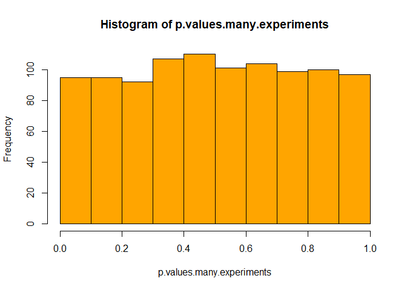

```r
hist(p.values.many.experiments,col="orange")
```

```r
sum(p.values.many.experiments<=.05)/B
```

```
## [1] 0.051
```

```r
#analogously for any other significance value:
sum(p.values.many.experiments<=.10)/B
```

```
## [1] 0.095
```

## 1.2 $H_1$ true

Now suppose we have the same previous setting, but in this case the drug works!

The answer of primary interest is still `Y`: (maximum) pressure and we have three subjects in each sample.

The hypothesis test of interest is the equality of the averages of the two samples.

**Exercise**

1. Generate a *plausible* dataset under the assumption that the two drugs are different.
2. Now compute a statistical test (and associated p-values) to test if the two drugs are equivalent.
3. Did you reject $H_0: \mu_{standard}=\mu_{new}$? Are you surprised?

**Possible solution**

```r
set.seed(17)
datas=data.frame(drug=c("standard","standard","standard",
                        "new","new","new"),
                pressure=rnorm(6,mean = c(150,150,150,150-30,150-30,150-30),sd = 10))
datas
```

| drug | pressure |
| --- | --- |
| standard | 139.8499 |
| standard | 149.2036 |
| standard | 147.6701 |
| new | 111.8273 |
| new | 127.7209 |
| new | 118.3439 |

```r
t.test(pressure~drug,data=datas)
```

```
##
##  Welch Two Sample t-test
##
## data:  pressure by drug
## t = -4.8244, df = 3.3649, p-value = 0.01297
## alternative hypothesis: true difference in means between group new and group standard is not equal to 0
## 95 percent confidence interval:
##  -42.594756  -9.959621
## sample estimates:
##      mean in group new mean in group standard
##               119.2974               145.5746
```

Here, we suppose that the mean pressure of our patients is $\mu=150$ with dev.std $\sigma=10$. The drug reduces the pressure by $30$.

**Exercise**

1. Check the proportion of rejections by simulation in `R`!

**Possible solution**

```r
B=1000
p.values.many.experiments=replicate(B,{
  dati=data.frame(farmaco=c("standard","standard","standard",
                          "new","new","new"),
                  pressione=rnorm(6,mean =  c(150,150,150,150-30,150-30,150-30),sd = 10))
  t.test(pressione~farmaco,data=dati)$p.value
}
)

sum(p.values.many.experiments<.05)
```

```
## [1] 684
```

> The p-value under $H_1$ is a random variable with stochastically less than a $U(0,1)$ and therefore the probability of rejecting the null hypothesis CORRECTLY is $>\alpha$: $P(p\leq\alpha|H_1)>\alpha$

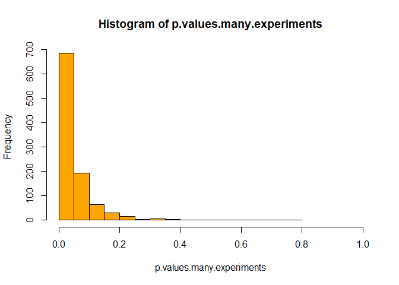

```r
hist(p.values.many.experiments,xlim=c(0,1),col="orange")
```

```r
sum(p.values.many.experiments<=.05)/B
```

```
## [1] 0.684
```

```r
#analogously for any other significance value:
sum(p.values.many.experiments<=.10)/B
```

```
## [1] 0.876
```

# 2 Multiple hypotheses

Now suppose that in the same experiment (more realistically) we evaluate multiple endpoints of interest and not just maximum pressure. For each endpoint we evaluate a hypothesis and obtain a p-value.

**Exercise**

1. Simulate 1000 clinical trials with 18 endpoints under $H_0$,
2. Evaluate the empirical distribution of the **number of rejections** in each trial,
3. Evaluate the fraction of experiments in which **at least one error** was made,

considering two different thresholds:

- `alpha_a=.05`
- `alpha_b=1-(1-.05)^(1/m)=` 0.0028456 (Sidak’s correction)

**Possible solution**

```r
m=18
B = 1000
alpha_a=.05
alpha_b=1-(1-.05)^(1/m)
#### A single experiment with m endpoints (and as many hypothesis tests and p-values).

endpoints=matrix(rnorm(6*m),6,m)

p.values.1.experiment=apply(endpoints , 2,
                            function(y)
                              t.test(y[1:3],y[4:6],
                                     var.equal = TRUE)$p.value)

 c(n.rifiuti_a=sum(p.values.1.experiment<alpha_a),
   n.rifiuti_b=sum(p.values.1.experiment<alpha_b))
```

```
## n.rifiuti_a n.rifiuti_b
##           3           0
```

```r
# replicate B times
res=replicate(B,
              {
 endpoints=matrix(rnorm(6*m),6,m)

 p.values.1.experiment=apply(endpoints , 2,
                             function(y) t.test(y[1:3],y[4:6],
                                                var.equal = TRUE)$p.value)
 c(n.rifiuti_a=sum(p.values.1.experiment<alpha_a),
   n.rifiuti_b=sum(p.values.1.experiment<alpha_b))
}
)
dim(res)
```

```
## [1]    2 1000
```

```r
#Number of rejections:
table(res["n.rifiuti_a",])
```

```
##
##   0   1   2   3   4   5
## 380 387 178  47   7   1
```

```r
# How many times have we made at least one mistake? (= how many times at least one rejection?)
sum(res["n.rifiuti_a",]>0)
```

```
## [1] 620
```

```r
table(res["n.rifiuti_b",])
```

```
##
##   0   1
## 952  48
```

```r
sum(res["n.rifiuti_b",]>0)
```

```
## [1] 48
```

Let us now assume that the drug affects the first 5 endpoints and not the others.

**Exercise**

1. Simulate 1000 clinical trials with 18 endpoints where the drug affects the first 5 endpoints.
2. Evaluate the empirical distribution of the **number of rejections** in each trial.
3. Evaluate the fraction of experiments in which **at least one error** was made.

considering two different thresholds:

- `alpha_a=.05`
- `alpha_b=1-(1-.05)^(1/m)=` 0.0028456 (Sidak’s correction)

**Possible solution**

```r
# Generate the response of 6 patients on m enpoint.
endpoints=matrix(rnorm(6*m),6,m)

# Added a value of 3 to the values reported
# to the first 5 endpoints for the three patients with the drug new

endpoints[4:6,1:5]= endpoints[4:6,1:5]+3

endpoints
```

```
##            [,1]        [,2]        [,3]        [,4]       [,5]       [,6]
## [1,] -0.8042365 -0.47723362 -0.09853936  1.90344675 -1.0642840 -0.6428483
## [2,]  0.3027326  0.02039881  0.59483667  0.08102408 -0.4880139 -1.0932948
## [3,] -3.3609780 -0.78710828  0.18723548 -1.33842956 -0.1431656 -1.0377388
## [4,]  3.0804916  3.77286283  3.30777236  2.95434312  3.4418012  0.6660882
## [5,]  3.6455054  2.74031784  2.85694214  3.36790875  2.3881346  0.1018607
## [6,]  1.9446001  3.73738139  3.96980253  5.05561871  2.5709344  0.4886592
##            [,7]        [,8]       [,9]      [,10]      [,11]      [,12]
## [1,]  1.5942527 -0.34146109  0.7866683 -0.1651197 -0.3100599  0.9801810
## [2,] -0.3613058  0.97210216  1.7985122 -1.6658747 -0.9713647 -0.5237810
## [3,] -0.4974855 -0.06256713  0.3515879  0.7164010 -0.2639730 -0.4785343
## [4,]  0.8146074  0.60813623 -0.8524083  1.6412034  0.2708066 -1.2024163
## [5,]  0.6375054  1.86849525  1.1812835  0.4591089 -0.1110320 -1.3092998
## [6,]  0.8966281 -0.34575897  1.1026451 -0.3221929 -0.7889634 -0.5026815
##            [,13]        [,14]      [,15]       [,16]      [,17]      [,18]
## [1,] -0.03875883  0.003634702  0.3566331  1.11531840 -2.3310520  0.5502076
## [2,]  0.32113600 -0.756320542 -0.2785701 -0.44351847  0.7217385  1.9695337
## [3,]  0.69306802  1.126330789 -0.3485627 -2.26275684  1.5551560 -0.5626118
## [4,]  0.16502187  0.841082854 -0.8788129 -0.68358299  0.4881190 -1.0912691
## [5,]  0.50884935  0.660860572 -0.3572377  0.08755564 -2.5196310  0.5242624
## [6,] -0.46512329  0.159473158  1.5146301  0.17957089  0.8089571 -0.1322751
```

```r
p.values.1.experiment=apply(endpoints , 2,
                            function(y) t.test(y[1:3],y[4:6])$p.value)

 c(n.rifiuti_a=sum(p.values.1.experiment<alpha_a),
   n.rifiuti_b=sum(p.values.1.experiment<alpha_b),
   n.rifiuti_a_H0=sum(p.values.1.experiment[-(1:5)]<alpha_a),
   n.rifiuti_b_H0=sum(p.values.1.experiment[-(1:5)]<alpha_b),
   n.rifiuti_a_H1=sum(p.values.1.experiment[1:5]<alpha_a),
   n.rifiuti_b_H1=sum(p.values.1.experiment[1:5]<alpha_b))
```

```
##    n.rifiuti_a    n.rifiuti_b n.rifiuti_a_H0 n.rifiuti_b_H0 n.rifiuti_a_H1
##              6              3              1              0              5
## n.rifiuti_b_H1
##              3
```

```r
p.values.1.experiment
```

```
##  [1] 0.043738527 0.001262447 0.002427531 0.041045566 0.001544470 0.003868907
##  [7] 0.510136383 0.535270110 0.565967044 0.346279417 0.475664030 0.170708925
## [13] 0.514467199 0.523873544 0.829012855 0.732050586 0.818371649 0.375600048
```

The first 5 p-values tend to have lower values than the others (I reject those hypotheses several times).

In applications to real data we obviously do NOT know which hypotheses are under $H_0$ (the two drugs are equal) and which are under $H_1$ (the new drug is better).